# homeworksheet 2: Importing data files practice

Jeffrey A. Walker

9/2/2021

# Import

In almost any software, the menu item **Open** opens a file created by that software while the menu item **Import** opens a file created by some other software. R has a native file format but we will be working with data files created in Excel or created in a text editor (a **text file**). This means we need to Import using a function that knows how to open an Excel file or a function that knows how to open a text file.

The gist of import. Starting with “okay, this is important”, come back to this frequently to understand what is going on.

- the data to import are on a **hard drive** on your computer. R can also import data that is archived on the web and is not on your hard drive. The physical changes on the hard drive used to store these data are permanently there until you trash the file AND write over this with new stuff (this is why you can recover stuff that has been trashed, at least if it hasn’t been written over yet).
- when you import data into R, the data are in **RAM** or, Random Access Memory. RAM is not permanent storage but only storing while your R session is running. If you quit R (or shut down your computer), the data are lost. This is a feature, not a bug. If this didn’t happen, then your RAM would quickly will up with everything you do and you’d have no space for new stuff. But, it doesn’t matter because we start each new R session by re-imorting the data.
- **okay this is important** the imported data are assigned to an R object called a **data frame**. You give the data frame a name. In homeworksheet 1, we called the data frame containing the $\texttt{mar}$ data `exp4e`, which combines the abbreviation for “experiment” and the figure number in the published paper containing the data.
- There are some special kinds of data frames. One is a “tibble” which is super popular now in the R universe. Tibbles are part of the “tidyverse”. We aren’t using these in this class because we are using…
- Another special kind of data frame is a **data table**, which I usually write as “data.table”. A data.table *is* a data frame but a data frame is not necessarily a data.table in the same way an olympic 100 m sprinter *is* a human but a human is not necessarily an olympic 100 m sprinter. data.tables have features not shared by base data frames. Olympic 100 m sprinters have features not shared by all humans – they’ve been transformed. The package `data.table` has the functions to transform data frames into data tables.

# Beclin data

Data source: [Fernández, Álvaro F., et al. “Disruption of the beclin 1–BCL2 autophagy regulatory complex promotes longevity in mice.” Nature 558.7708 (2018): 136-140.](https://www.nature.com/articles/s41586-018-0162-7)

data file name: Fernandez-beclin.xlsx

Step 1 – Create an import chunk that imports the data. Call the imported data `exp3b`. I’m not giving you the code for this chunk…you need to create it (its the point of this homework) using the information in Chapter 2 and in the first homework sheet (and in the template.Rmd file)

Step 2. Copy this model-fit chunk and run it.

```r
m1 <- lm(positive_nuclei_per_area ~ genotype,
         data = exp3b)
m1_emm <- emmeans(m1, specs = "genotype")
m1_pairs <- contrast(m1_emm,
                     method = "revpairwise") %>%
  summary(infer = TRUE)

m1_pairs
```

```
##  contrast estimate    SE df lower.CL upper.CL t.ratio p.value
##  wt - ki      1.17 0.557 44   0.0517      2.3   2.108  0.0407
##
## Confidence level used: 0.95
```

Step 3. Copy this plot chunk and run it.

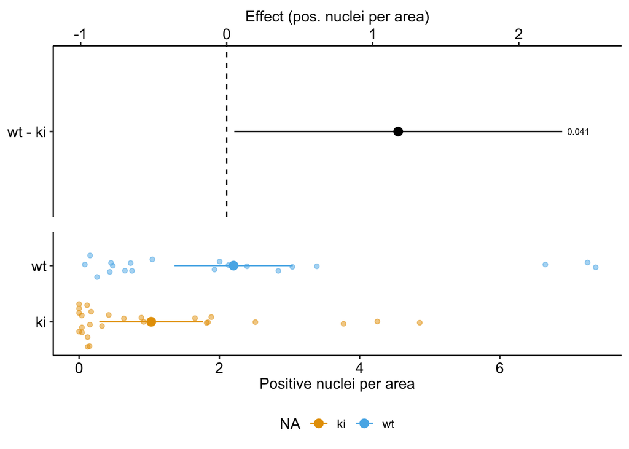

```r
ggplot_the_model(m1, m1_emm, m1_pairs,
                 y_label = "Positive nuclei per area",
                 effect_label = "Effect (pos. nuclei per area)")
```

# BCAA data

Data source: [Yoneshiro, Takeshi, et al. “BCAA catabolism in brown fat controls energy homeostasis through SLC25A44.” Nature 572.7771 (2019): 614-619.](https://www.nature.com/articles/s41586-019-1503-x)

data file name: yoneshiro_2019_bcaa.xlsx

Step 1 – Create an import chunk that imports the data. Call the imported data `exp2g`. I’m not giving you the code for this chunk…you need to create it (its the point of this homework) using the information in Chapter 2 and in the first homework sheet (and in the template.Rmd file)

The data are multiple measures of blood glucose on each mouse (measures at 0, 15, 30, 60, 90 and 120 minutes) in what is known as a glucose tolerance test. The data are in wide format for how we want to plot the data. We need to reshape the data to long format using the function melt from data.table (many R users use a function called pivot_longer from a different package)

Step 2. Copy this reshape chunk and run it.

```r
exp2g_long <- melt(exp2g,
                   id.vars = c("treatment", "mouse_id"),
                   measure.vars = c("glucose0", "glucose15", "glucose30",
                                    "glucose60", "glucose90", "glucose120"),
                   variable.name = "period",
                   value.name = "glucose")
# extract time from period name
exp2g_long[, time := substr(period, 8, nchar(as.character(period)))]

# convert time to numeric
exp2g_long[, time := as.numeric(time)]

# dodge time
exp2g_long[, time_dodge := ifelse(treatment == "WT",
                                  time - 1,
                                  time + 1)]
```

Step 3. Copy this Plot chunk and run it.

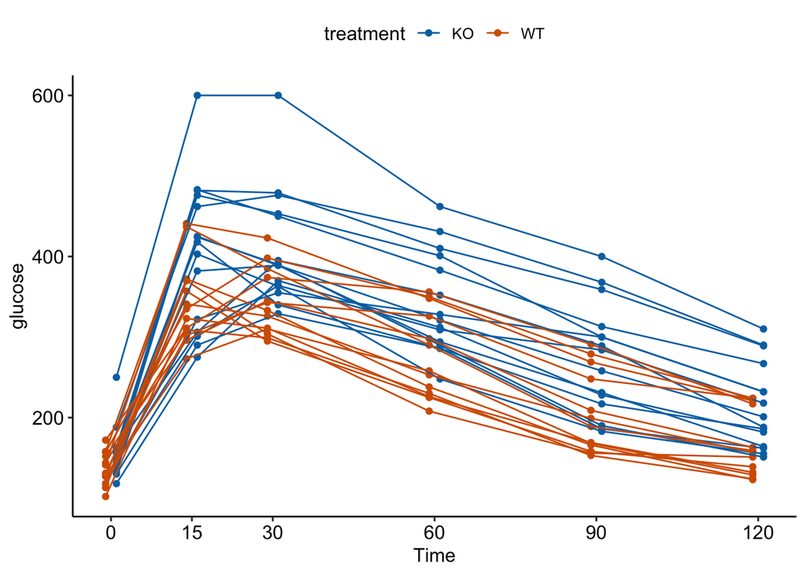

```r
gg <- ggplot(data = exp2g_long,
             aes(x = time_dodge,
                 y = glucose,
                 color = treatment,
                 group = mouse_id)) +
  geom_point() +
  geom_line() +
  scale_x_continuous(
    breaks = c(0, 15, 30, 60, 90, 120),
    labels = c("0", "15", "30", "60", "90", "120")) +
  xlab("Time") +
  scale_color_manual(values = pal_okabe_ito_2) +
  theme_pubr()

gg
```

# Import big mice data

Data source: [Corrigan, June K., et al. “A big-data approach to understanding metabolic rate and response to obesity in laboratory mice.” Elife 9 (2020): e53560.](https://elifesciences.org/articles/53560)

file name: mmpc_all_phases.csv

A .csv file is a type of “text” file. If the extension of a text file is .txt, the values are separated by tabs instead of commas.

Look at chapter 3.4 in the textbook for importing text files. And look at the template.Rmd file for an example.

Step 1 – Create an import chunk that imports the data. Call the imported data `exp1`. I’m not giving you the code for this chunk…you need to create it (its the point of this homework) using the information in Chapter 2 and in the first homework sheet (and in the template.Rmd file)

Use the function clean_names after you import. Be sure to have this line at the *end* of your setup chunk

`clean_names <- janitor::clean_names`

Step 2. Copy this plot chunk and run it.

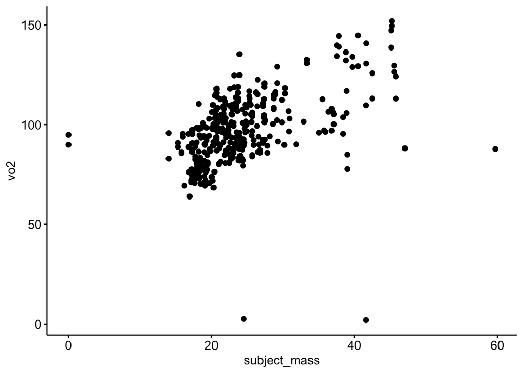

```r
ggscatter(data = exp1,
          x = "subject_mass",
          y = "vo2")
```

Ooh, there are a couple of mice with missing VO2 measures but these have some wonky number. Let’s exclude these.

Step 3. Copy this plot chunk and run it.

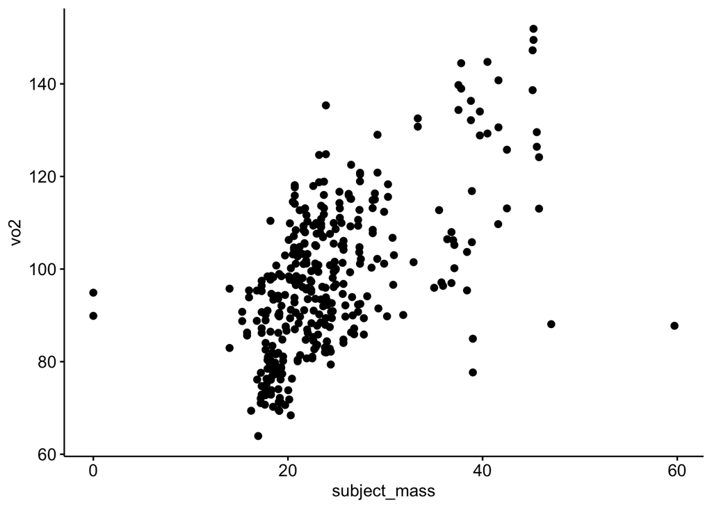

```r
ggscatter(data = exp1[vo2 > 25,],
          x = "subject_mass",
          y = "vo2")
```